# Analyse d’expression différentielle mutli-facteurs : Fer, Azote et CO2

Clustering et réseau pour les gènes répondant à chaque facteur

Océane Cassan

19/03/2020

On cherche à étudier comparer des méthode d’inférence de réseaux (co-expression et régulation).

# Personalized functions

```r
genie <- function(normalized.count, regressors = NA, targets = NA, nTrees = 1000,
    nCores = 5, top = 0.05, fixedLinkNumber = NA, returnLinks = F) {


    print(head(normalized.count))
    print(intersect(rownames(normalized.count), regressors))
    print(targets)
    mat <- GENIE3(normalized.count, regulators = intersect(rownames(normalized.count),
        regressors), targets = targets, treeMethod = "RF", K = "sqrt", nTrees = nTrees,
        nCores = nCores, verbose = T)
    # hist(mat)
    links <- getLinkList(mat)

    if (returnLinks) {
        return(links)
    }

    if (is.na(fixedLinkNumber))
        links <- links[1:round(dim(links)[1] * top, 0), ] else links <- links[1:fixedLinkNumber, ]


    print(paste0("Number of links : ", dim(links)[1]))

    g <- graph.data.frame(links, directed = F)
    return(g)

}


plotStats <- function(net) {

    ont <- ontologies[match(V(net)$name, ontologies$ensembl_gene_id), ]
    data <- toVisNetworkData(net)

    # attributs des noeuds et des liens
    data$nodes$Ontology <- ont[match(data$nodes$id, ont$ensembl_gene_id), ]$external_gene_name
    data$nodes$description <- ont[match(data$nodes$id, ont$ensembl_gene_id), ]$description
    data$nodes$group <- ifelse(data$nodes$id %in% TF$AGI, "Regulator", "Target Gene")

    importance <- (degree(net)/max(degree(net)) + betweenness(net)/max(betweenness(net))) *
        0.5

    data$nodes$ranking <- importance[match(data$nodes$id, names(importance))]
    data$edges$value <- data$edges$weight
    netStats(net)
    # plot
    net <- visNetwork(nodes = data$nodes, edges = data$edges) %>% visEdges(smooth = FALSE,
        color = "#333366") %>% # visEdges(smooth = FALSE, arrows = 'to', color = '#333366') %>%
    visPhysics(solver = "forceAtlas2Based", timestep = 0.9, minVelocity = 10, maxVelocity = 10,
        stabilization = F) %>% visOptions(selectedBy = "group", highlightNearest = TRUE,
        nodesIdSelection = TRUE, collapse = TRUE) %>% visEvents(click = "function(nodes){
                  Shiny.onInputChange('click', nodes.nodes);
                  ;}") %>%
        visGroups(groupname = "Regulator", size = 28, color = list(background = "#003399",
            border = "#FFFFCC"), shape = "square") %>% visGroups(groupname = "Target Gene",
        color = "#77EEAA") %>% visNodes(borderWidth = 0.5)

    print(kable(head(data$nodes[order(-data$nodes$ranking), ], n = 20)))

    return(net)
}
```

# Know regulators as regressors

```
               cNF_3      cNF_2      cNF_1      cnF_2      cnF_1      cnF_3
AT1G01010 1404.48413 1137.14606 1370.49722 1234.59407  975.10562 1079.37253
AT1G01020  382.87379  322.15371  354.90475  337.93987  367.05113  392.30632
AT1G01030   28.53146   16.95546   23.33284   28.08096   36.30176   29.68805
               CNF_1      CnF_2      CnF_1      CnF_3      cNf_1      cnf_2
AT1G01010 1464.91355 1068.19624 1184.65014 1186.87210 2176.34766 2035.52449
AT1G01020  387.67033  484.08540  459.57834  488.14901  431.52528  392.07689
AT1G01030   20.58427   44.35090   31.12682   40.89662   16.84914   38.53336
               cnf_1      cNf_2      cNf_3      cnf_3     Cnf_3      CNf_1
AT1G01010 1879.40582 2023.32331 2118.16807 1941.68207 1766.0503 1878.68429
AT1G01020  370.22495  484.52438  340.48387  469.97319  430.1804  432.82958
AT1G01030   27.42407   34.72162   33.15238   25.27744   37.3297   36.14637
              Cnf_1      Cnf_2      CNf_3      CNf_2      CNF_3      CNF_2
AT1G01010 1666.8990 1566.98344 1652.58184 1823.32023 1342.09996 1267.10176
AT1G01020  404.8455  383.20455  444.05745  443.82189  366.77487  433.48218
AT1G01030   34.2123   36.93538   39.78239   35.54418   24.67096   26.39795
 [ reached getOption("max.print") -- omitted 3 rows ]
 [1] "AT1G04990" "AT1G05830" "AT1G06160" "AT1G10610" "AT1G13260" "AT1G13300"
 [7] "AT1G18330" "AT1G21000" "AT1G22190" "AT1G25550" "AT1G25560" "AT1G26590"
[13] "AT1G26680" "AT1G27730" "AT1G28370" "AT1G29600" "AT1G32510" "AT1G34670"
[19] "AT1G43700" "AT1G46768" "AT1G57560" "AT1G58100" "AT1G62300" "AT1G64000"
[25] "AT1G64860" "AT1G68670" "AT1G68840" "AT1G69490" "AT1G71030" "AT1G72360"
[31] "AT1G72650" "AT1G72830" "AT1G73410" "AT1G76590" "AT1G77450" "AT1G78080"
[37] "AT2G01930" "AT2G14210" "AT2G18280" "AT2G19810" "AT2G20180" "AT2G20880"
[43] "AT2G21900" "AT2G25900" "AT2G28160" "AT2G29060" "AT2G31230" "AT2G41710"
[49] "AT2G43000" "AT2G45660" "AT2G46310" "AT2G46790" "AT2G47460" "AT2G47520"
[55] "AT3G01970" "AT3G02550" "AT3G02830" "AT3G02940" "AT3G03660" "AT3G04380"
[61] "AT3G06380" "AT3G10030" "AT3G11100" "AT3G15210" "AT3G15500" "AT3G16770"
[67] "AT3G19580" "AT3G19860" "AT3G24310" "AT3G25730" "AT3G30260" "AT3G46090"
[73] "AT3G47620" "AT3G48360" "AT3G49760"
 [ reached getOption("max.print") -- omitted 60 entries ]
 [1] "AT5G61600" "AT4G27450" "AT1G27730" "AT5G51190" "AT1G19530" "AT2G27830"
 [7] "AT4G27280" "AT5G13930" "AT3G44260" "AT5G04340" "AT2G40000" "AT1G33055"
[13] "AT4G27652" "AT5G56100" "AT1G65970" "AT5G19700" "AT3G16770" "AT4G27654"
[19] "AT1G76680" "AT2G48080" "AT2G38600" "AT2G25900" "AT1G05575" "AT3G19030"
[25] "AT4G11650" "AT4G08290" "AT1G73540" "AT5G05270" "AT4G32480" "AT1G54970"
[31] "AT2G34315" "AT2G15880" "AT5G14120" "AT5G51860" "AT3G23810" "AT4G24570"
[37] "AT1G29100" "AT1G18300" "AT5G63160" "AT5G07580" "AT4G29905" "AT5G13580"
[43] "AT2G38110" "AT4G39675" "AT3G57020" "AT3G29000" "AT1G28370" "AT1G70290"
[49] "AT5G66052" "AT5G09520" "AT4G17500" "AT3G54500" "AT1G76590" "AT4G27657"
[55] "AT1G01470" "AT5G39890" "AT4G37520" "AT5G19410" "AT1G49500" "AT3G50400"
[61] "AT1G66500" "AT5G09480" "AT2G39980" "AT4G22690" "AT3G14940" "AT2G18050"
[67] "AT2G35380" "AT5G08640" "AT1G69252" "AT1G73260" "AT1G04220" "AT5G37690"
[73] "AT3G22120" "AT3G23880" "AT2G37750"
 [ reached getOption("max.print") -- omitted 1234 entries ]
[1] "Number of links : 600"
```

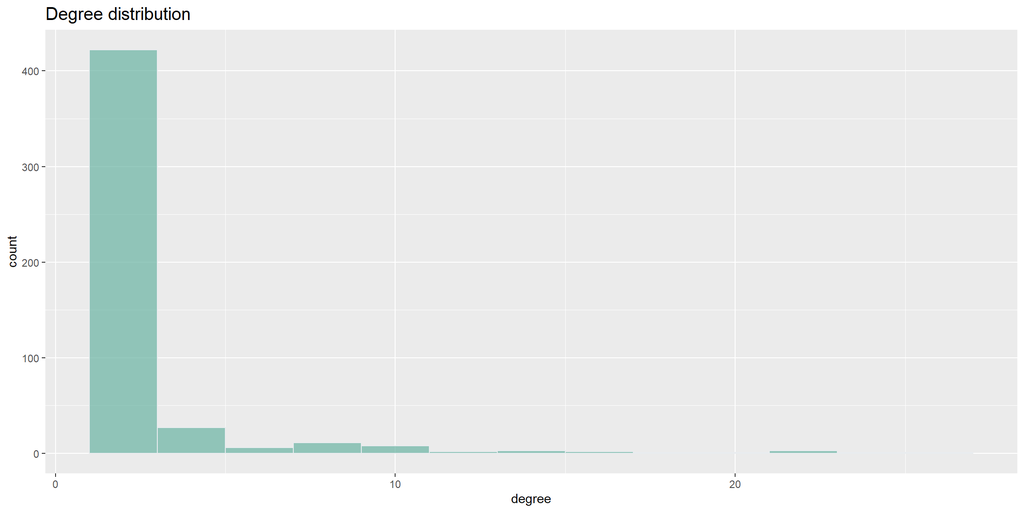

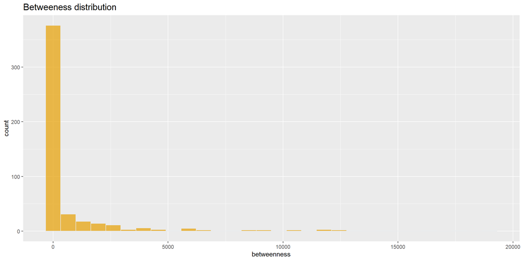

```
            id          label       Ontology   description                                                                                            group            ranking
----------  ----------  ----------  ---------  -----------------------------------------------------------------------------------------------------  ------------  ----------
AT3G25730   AT3G25730   AT3G25730   ARF14      AP2/ERF and B3 domain-containing transcription factor ARF14 [Source:UniProtKB/Swiss-Prot;Acc:Q9LS06]   Regulator      0.9230769
AT1G28370   AT1G28370   AT1G28370   ERF11      ERF domain protein 11 [Source:TAIR;Acc:AT1G28370]                                                      Regulator      0.9137242
AT3G03660   AT3G03660   AT3G03660   WOX11      WUSCHEL related homeobox 11 [Source:UniProtKB/TrEMBL;Acc:A0A1I9LND8]                                   Regulator      0.7291148
AT3G02550   AT3G02550   AT3G02550   LBD41      LOB domain-containing protein 41 [Source:UniProtKB/Swiss-Prot;Acc:Q9M886]                              Regulator      0.6759113
AT3G48360   AT3G48360   AT3G48360   BT2        BTB/POZ and TAZ domain-containing protein 2 [Source:UniProtKB/Swiss-Prot;Acc:Q94BN0]                   Regulator      0.6724935
AT4G11880   AT4G11880   AT4G11880   AGL14      Agamous-like MADS-box protein AGL14 [Source:UniProtKB/Swiss-Prot;Acc:Q38838]                           Regulator      0.6253470
AT5G16770   AT5G16770   AT5G16770   AtMYB9     Myb domain protein 9 [Source:UniProtKB/TrEMBL;Acc:F4KE69]                                              Regulator      0.5941411
AT5G65230   AT5G65230   AT5G65230   AtMYB53    Transcription factor MYB53 [Source:UniProtKB/Swiss-Prot;Acc:Q9FJP2]                                    Regulator      0.5551844
AT3G01970   AT3G01970   AT3G01970   WRKY45     Probable WRKY transcription factor 45 [Source:UniProtKB/Swiss-Prot;Acc:Q9S763]                         Regulator      0.4902983
AT3G19580   AT3G19580   AT3G19580   AZF2       ZF2 [Source:UniProtKB/TrEMBL;Acc:A0A178VJ97]                                                           Regulator      0.4675654
AT1G17180   AT1G17180   AT1G17180   GSTU25     Glutathione S-transferase U25 [Source:UniProtKB/Swiss-Prot;Acc:Q9SHH7]                                 Target Gene    0.4594976
AT4G29190   AT4G29190   AT4G29190              Zinc finger CCCH domain-containing protein 49 [Source:UniProtKB/Swiss-Prot;Acc:Q9M0G2]                 Regulator      0.4379183
AT5G47220   AT5G47220   AT5G47220   ERF2       ERF2 [Source:UniProtKB/TrEMBL;Acc:A0A178UCP3]                                                          Regulator      0.4320114
AT1G34670   AT1G34670   AT1G34670   AtMYB93    Transcription factor MYB93 [Source:UniProtKB/Swiss-Prot;Acc:Q9S9Z2]                                    Regulator      0.4284886
AT2G47520   AT2G47520   AT2G47520   ERF071     Ethylene-responsive transcription factor ERF071 [Source:UniProtKB/Swiss-Prot;Acc:O22259]               Regulator      0.3938087
AT3G01175   AT3G01175   AT3G01175              Transmembrane protein [Source:UniProtKB/TrEMBL;Acc:F4J4Q8]                                             Target Gene    0.3925388
AT2G29060   AT2G29060   AT2G29060   SCL33      Scarecrow-like protein 33 [Source:UniProtKB/Swiss-Prot;Acc:P0C883]                                     Regulator      0.3756997
AT5G07310   AT5G07310   AT5G07310   ERF115     Ethylene-responsive transcription factor ERF115 [Source:UniProtKB/Swiss-Prot;Acc:Q9LY29]               Regulator      0.3672154
AT5G61590   AT5G61590   AT5G61590   ERF107     Ethylene-responsive transcription factor ERF107 [Source:UniProtKB/Swiss-Prot;Acc:Q9FKG2]               Regulator      0.3605863
AT5G41570   AT5G41570   AT5G41570   WRKY24     Probable WRKY transcription factor 24 [Source:UniProtKB/Swiss-Prot;Acc:Q9FFS3]                         Regulator      0.3447995
```

[interactive chart not shown]

```r
plotStats(genie(normalized.count, regressors = intersect(genes, TF$AGI), targets = genes,
    fixedLinkNumber = 600))
```

# All genes as regressors

```
               cNF_3      cNF_2      cNF_1      cnF_2      cnF_1      cnF_3
AT1G01010 1404.48413 1137.14606 1370.49722 1234.59407  975.10562 1079.37253
AT1G01020  382.87379  322.15371  354.90475  337.93987  367.05113  392.30632
AT1G01030   28.53146   16.95546   23.33284   28.08096   36.30176   29.68805
               CNF_1      CnF_2      CnF_1      CnF_3      cNf_1      cnf_2
AT1G01010 1464.91355 1068.19624 1184.65014 1186.87210 2176.34766 2035.52449
AT1G01020  387.67033  484.08540  459.57834  488.14901  431.52528  392.07689
AT1G01030   20.58427   44.35090   31.12682   40.89662   16.84914   38.53336
               cnf_1      cNf_2      cNf_3      cnf_3     Cnf_3      CNf_1
AT1G01010 1879.40582 2023.32331 2118.16807 1941.68207 1766.0503 1878.68429
AT1G01020  370.22495  484.52438  340.48387  469.97319  430.1804  432.82958
AT1G01030   27.42407   34.72162   33.15238   25.27744   37.3297   36.14637
              Cnf_1      Cnf_2      CNf_3      CNf_2      CNF_3      CNF_2
AT1G01010 1666.8990 1566.98344 1652.58184 1823.32023 1342.09996 1267.10176
AT1G01020  404.8455  383.20455  444.05745  443.82189  366.77487  433.48218
AT1G01030   34.2123   36.93538   39.78239   35.54418   24.67096   26.39795
 [ reached getOption("max.print") -- omitted 3 rows ]
 [1] "AT1G01020" "AT1G01090" "AT1G01160" "AT1G01170" "AT1G01470" "AT1G01600"
 [7] "AT1G01610" "AT1G01770" "AT1G01820" "AT1G02300" "AT1G02610" "AT1G02640"
[13] "AT1G02730" "AT1G02840" "AT1G02860" "AT1G03060" "AT1G03090" "AT1G03457"
[19] "AT1G03610" "AT1G03700" "AT1G03850" "AT1G03935" "AT1G04120" "AT1G04220"
[25] "AT1G04360" "AT1G04990" "AT1G05000" "AT1G05575" "AT1G05700" "AT1G05830"
[31] "AT1G05840" "AT1G05890" "AT1G06000" "AT1G06160" "AT1G06570" "AT1G06630"
[37] "AT1G07135" "AT1G08090" "AT1G08230" "AT1G08630" "AT1G08980" "AT1G09070"
[43] "AT1G09140" "AT1G09250" "AT1G09280" "AT1G09780" "AT1G09932" "AT1G10070"
[49] "AT1G10140" "AT1G10220" "AT1G10610" "AT1G10910" "AT1G10920" "AT1G11175"
[55] "AT1G11180" "AT1G11185" "AT1G11260" "AT1G11530" "AT1G11790" "AT1G11920"
[61] "AT1G12010" "AT1G12040" "AT1G12110" "AT1G12440" "AT1G12780" "AT1G12805"
[67] "AT1G13080" "AT1G13250" "AT1G13260" "AT1G13300" "AT1G13710" "AT1G14200"
[73] "AT1G14540" "AT1G14550" "AT1G14640"
 [ reached getOption("max.print") -- omitted 1234 entries ]
 [1] "AT5G61600" "AT4G27450" "AT1G27730" "AT5G51190" "AT1G19530" "AT2G27830"
 [7] "AT4G27280" "AT5G13930" "AT3G44260" "AT5G04340" "AT2G40000" "AT1G33055"
[13] "AT4G27652" "AT5G56100" "AT1G65970" "AT5G19700" "AT3G16770" "AT4G27654"
[19] "AT1G76680" "AT2G48080" "AT2G38600" "AT2G25900" "AT1G05575" "AT3G19030"
[25] "AT4G11650" "AT4G08290" "AT1G73540" "AT5G05270" "AT4G32480" "AT1G54970"
[31] "AT2G34315" "AT2G15880" "AT5G14120" "AT5G51860" "AT3G23810" "AT4G24570"
[37] "AT1G29100" "AT1G18300" "AT5G63160" "AT5G07580" "AT4G29905" "AT5G13580"
[43] "AT2G38110" "AT4G39675" "AT3G57020" "AT3G29000" "AT1G28370" "AT1G70290"
[49] "AT5G66052" "AT5G09520" "AT4G17500" "AT3G54500" "AT1G76590" "AT4G27657"
[55] "AT1G01470" "AT5G39890" "AT4G37520" "AT5G19410" "AT1G49500" "AT3G50400"
[61] "AT1G66500" "AT5G09480" "AT2G39980" "AT4G22690" "AT3G14940" "AT2G18050"
[67] "AT2G35380" "AT5G08640" "AT1G69252" "AT1G73260" "AT1G04220" "AT5G37690"
[73] "AT3G22120" "AT3G23880" "AT2G37750"
 [ reached getOption("max.print") -- omitted 1234 entries ]
[1] "Number of links : 600"
```

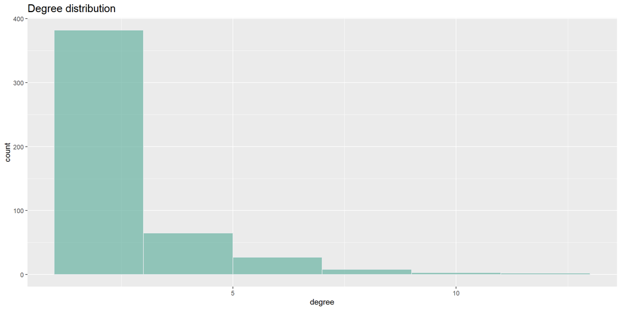

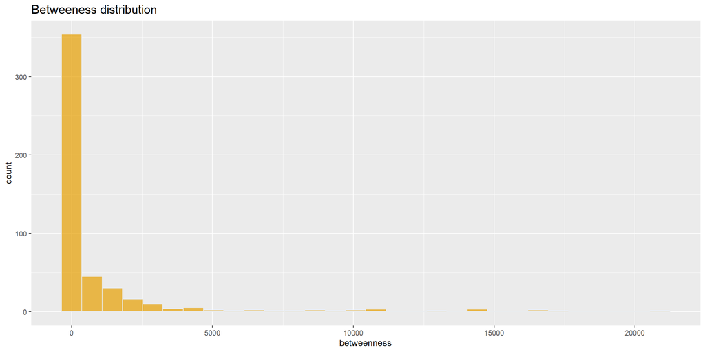

```
            id          label       Ontology   description                                                                                            group            ranking
----------  ----------  ----------  ---------  -----------------------------------------------------------------------------------------------------  ------------  ----------
AT2G45360   AT2G45360   AT2G45360              Ankyrin repeat/KH domain protein (DUF1442) [Source:UniProtKB/TrEMBL;Acc:O22136]                        Target Gene    1.0000000
AT5G66480   AT5G66480   AT5G66480              Bacteriophage N4 adsorption B protein [Source:UniProtKB/TrEMBL;Acc:Q93ZY1]                             Target Gene    0.6475042
AT5G07310   AT5G07310   AT5G07310   ERF115     Ethylene-responsive transcription factor ERF115 [Source:UniProtKB/Swiss-Prot;Acc:Q9LY29]               Regulator      0.6050696
AT5G18140   AT5G18140   AT5G18140              Chaperone DnaJ-domain superfamily protein [Source:UniProtKB/TrEMBL;Acc:Q9FK56]                         Target Gene    0.5729302
AT2G41380   AT2G41380   AT2G41380              At2g41380 [Source:UniProtKB/TrEMBL;Acc:Q9ZVC3]                                                         Target Gene    0.5284677
AT5G39890   AT5G39890   AT5G39890   PCO2       Plant cysteine oxidase 2 [Source:UniProtKB/Swiss-Prot;Acc:Q8LGJ5]                                      Target Gene    0.5005040
AT3G01175   AT3G01175   AT3G01175              Transmembrane protein [Source:UniProtKB/TrEMBL;Acc:F4J4Q8]                                             Target Gene    0.4962863
AT1G73500   AT1G73500   AT1G73500   MKK9       Mitogen-activated protein kinase kinase 9 [Source:UniProtKB/Swiss-Prot;Acc:Q9FX43]                     Target Gene    0.4880310
AT5G15960   AT5G15960   AT5G15960   KIN1       Stress-induced protein KIN1 [Source:UniProtKB/Swiss-Prot;Acc:P18612]                                   Target Gene    0.4665647
AT4G27450   AT4G27450   AT4G27450              AT4g27450/F27G19_50 [Source:UniProtKB/TrEMBL;Acc:Q93V62]                                               Target Gene    0.4599652
AT2G34390   AT2G34390   AT2G34390   NIP2-1     Aquaporin NIP2-1 [Source:UniProtKB/Swiss-Prot;Acc:Q8W037]                                              Target Gene    0.4589333
AT5G27420   AT5G27420   AT5G27420   ATL31      E3 ubiquitin-protein ligase ATL31 [Source:UniProtKB/Swiss-Prot;Acc:Q8LGA5]                             Target Gene    0.4569294
AT4G14440   AT4G14440   AT4G14440   ECI3       Enoyl-CoA delta isomerase 3 [Source:UniProtKB/Swiss-Prot;Acc:O23300]                                   Target Gene    0.4498920
AT1G78990   AT1G78990   AT1G78990              HXXXD-type acyl-transferase family protein [Source:UniProtKB/TrEMBL;Acc:F4IDH0]                        Target Gene    0.4409167
AT1G74460   AT1G74460   AT1G74460              GDSL esterase/lipase At1g74460 [Source:UniProtKB/Swiss-Prot;Acc:Q9CA68]                                Target Gene    0.4402988
AT4G26555   AT4G26555   AT4G26555   FKBP16-1   Peptidyl-prolyl cis-trans isomerase FKBP16-1, chloroplastic [Source:UniProtKB/Swiss-Prot;Acc:Q944B0]   Target Gene    0.4260979
AT1G80920   AT1G80920   AT1G80920   ATJ8       Chaperone protein dnaJ 8, chloroplastic [Source:UniProtKB/Swiss-Prot;Acc:Q9SAG8]                       Target Gene    0.4227622
AT3G23810   AT3G23810   AT3G23810   SAHH2      Adenosylhomocysteinase [Source:UniProtKB/TrEMBL;Acc:A0A178VEP9]                                        Target Gene    0.4222522
AT5G50140   AT5G50140   AT5G50140              Ankyrin repeat family protein [Source:UniProtKB/TrEMBL;Acc:Q9FG97]                                     Target Gene    0.4188925
AT3G06435   AT3G06435   AT3G06435              At3g06435 [Source:UniProtKB/TrEMBL;Acc:Q3EBB7]                                                         Target Gene    0.4173866
```

[interactive chart not shown]

```r
plotStats(genie(normalized.count, regressors = genes, targets = genes, fixedLinkNumber = 600))
```

# Thresold on links number effect

```r
links <- genie(normalized.count, targets = genes, regressors = intersect(genes, TF$AGI),
    returnLinks = T)
```

```
               cNF_3      cNF_2      cNF_1      cnF_2      cnF_1      cnF_3
AT1G01010 1404.48413 1137.14606 1370.49722 1234.59407  975.10562 1079.37253
AT1G01020  382.87379  322.15371  354.90475  337.93987  367.05113  392.30632
AT1G01030   28.53146   16.95546   23.33284   28.08096   36.30176   29.68805
               CNF_1      CnF_2      CnF_1      CnF_3      cNf_1      cnf_2
AT1G01010 1464.91355 1068.19624 1184.65014 1186.87210 2176.34766 2035.52449
AT1G01020  387.67033  484.08540  459.57834  488.14901  431.52528  392.07689
AT1G01030   20.58427   44.35090   31.12682   40.89662   16.84914   38.53336
               cnf_1      cNf_2      cNf_3      cnf_3     Cnf_3      CNf_1
AT1G01010 1879.40582 2023.32331 2118.16807 1941.68207 1766.0503 1878.68429
AT1G01020  370.22495  484.52438  340.48387  469.97319  430.1804  432.82958
AT1G01030   27.42407   34.72162   33.15238   25.27744   37.3297   36.14637
              Cnf_1      Cnf_2      CNf_3      CNf_2      CNF_3      CNF_2
AT1G01010 1666.8990 1566.98344 1652.58184 1823.32023 1342.09996 1267.10176
AT1G01020  404.8455  383.20455  444.05745  443.82189  366.77487  433.48218
AT1G01030   34.2123   36.93538   39.78239   35.54418   24.67096   26.39795
 [ reached getOption("max.print") -- omitted 3 rows ]
 [1] "AT1G04990" "AT1G05830" "AT1G06160" "AT1G10610" "AT1G13260" "AT1G13300"
 [7] "AT1G18330" "AT1G21000" "AT1G22190" "AT1G25550" "AT1G25560" "AT1G26590"
[13] "AT1G26680" "AT1G27730" "AT1G28370" "AT1G29600" "AT1G32510" "AT1G34670"
[19] "AT1G43700" "AT1G46768" "AT1G57560" "AT1G58100" "AT1G62300" "AT1G64000"
[25] "AT1G64860" "AT1G68670" "AT1G68840" "AT1G69490" "AT1G71030" "AT1G72360"
[31] "AT1G72650" "AT1G72830" "AT1G73410" "AT1G76590" "AT1G77450" "AT1G78080"
[37] "AT2G01930" "AT2G14210" "AT2G18280" "AT2G19810" "AT2G20180" "AT2G20880"
[43] "AT2G21900" "AT2G25900" "AT2G28160" "AT2G29060" "AT2G31230" "AT2G41710"
[49] "AT2G43000" "AT2G45660" "AT2G46310" "AT2G46790" "AT2G47460" "AT2G47520"
[55] "AT3G01970" "AT3G02550" "AT3G02830" "AT3G02940" "AT3G03660" "AT3G04380"
[61] "AT3G06380" "AT3G10030" "AT3G11100" "AT3G15210" "AT3G15500" "AT3G16770"
[67] "AT3G19580" "AT3G19860" "AT3G24310" "AT3G25730" "AT3G30260" "AT3G46090"
[73] "AT3G47620" "AT3G48360" "AT3G49760"
 [ reached getOption("max.print") -- omitted 60 entries ]
 [1] "AT5G61600" "AT4G27450" "AT1G27730" "AT5G51190" "AT1G19530" "AT2G27830"
 [7] "AT4G27280" "AT5G13930" "AT3G44260" "AT5G04340" "AT2G40000" "AT1G33055"
[13] "AT4G27652" "AT5G56100" "AT1G65970" "AT5G19700" "AT3G16770" "AT4G27654"
[19] "AT1G76680" "AT2G48080" "AT2G38600" "AT2G25900" "AT1G05575" "AT3G19030"
[25] "AT4G11650" "AT4G08290" "AT1G73540" "AT5G05270" "AT4G32480" "AT1G54970"
[31] "AT2G34315" "AT2G15880" "AT5G14120" "AT5G51860" "AT3G23810" "AT4G24570"
[37] "AT1G29100" "AT1G18300" "AT5G63160" "AT5G07580" "AT4G29905" "AT5G13580"
[43] "AT2G38110" "AT4G39675" "AT3G57020" "AT3G29000" "AT1G28370" "AT1G70290"
[49] "AT5G66052" "AT5G09520" "AT4G17500" "AT3G54500" "AT1G76590" "AT4G27657"
[55] "AT1G01470" "AT5G39890" "AT4G37520" "AT5G19410" "AT1G49500" "AT3G50400"
[61] "AT1G66500" "AT5G09480" "AT2G39980" "AT4G22690" "AT3G14940" "AT2G18050"
[67] "AT2G35380" "AT5G08640" "AT1G69252" "AT1G73260" "AT1G04220" "AT5G37690"
[73] "AT3G22120" "AT3G23880" "AT2G37750"
 [ reached getOption("max.print") -- omitted 1234 entries ]
```

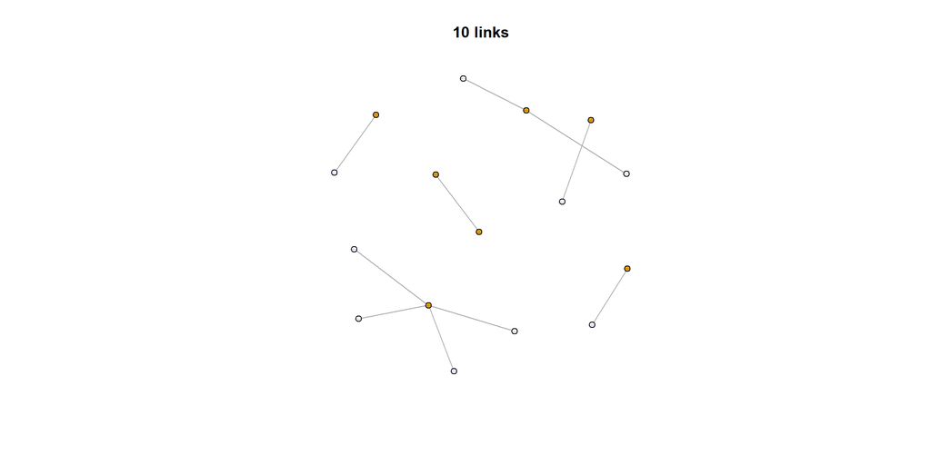

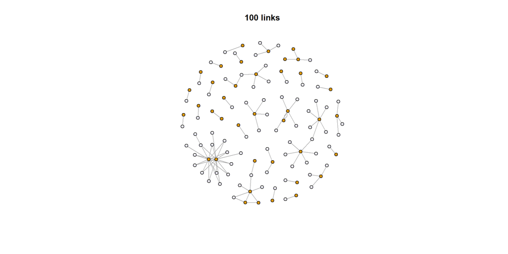

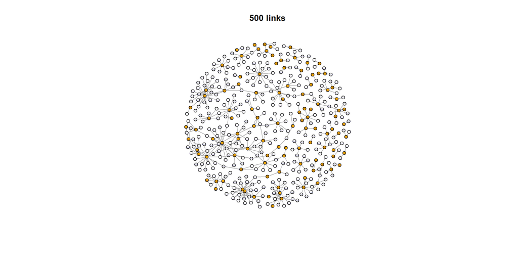

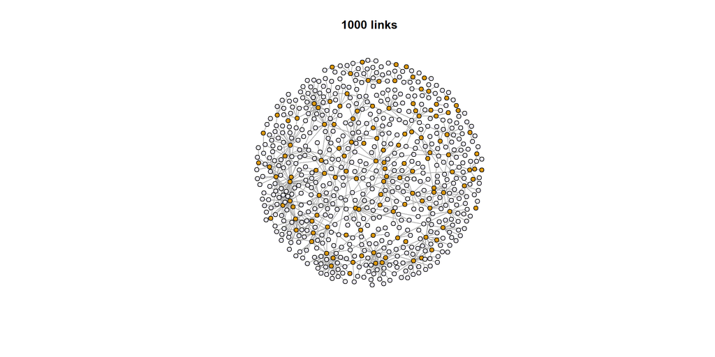

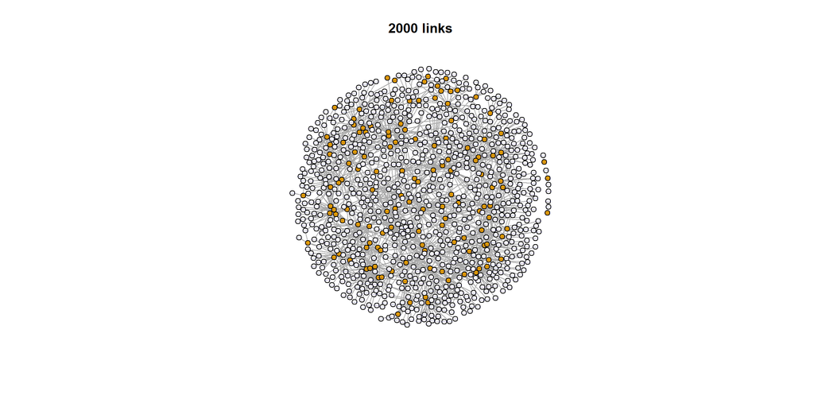

```r
for (nbLinks in c(10, 100, 500, 1000, 2000)) {
    newLinks <- links[1:nbLinks, ]
    g <- graph.data.frame(newLinks, directed = F)
    V(g)$color <- ifelse(V(g)$name %in% TF$AGI, 1, 0)
    plot.igraph(g, vertex.size = 4, vertex.label.cex = 0.1, color = V(g)$color, main = paste0(nbLinks,
        " links"))
}
```

# GENIE3 VS BC3NET

The basic idea of BC3NET is to generate from one dataset D_s, consisting of s samples, an ensem-ble of B independent bootstrap datasets D_k by sampling from $D(s)$ with replacement by using anon-parametric bootstrap (Efron 1993). Then, for each generated data set $D_k$ in the ensemble, anetwork $G^b_k$ is inferred by using C3NET (Altay 2010a). From the ensemble of networks $G^b_k$ we construct one weighted network $G^b_w$ which is used to determine the statistical significanceof the connection between gene pairs. This results in the final binary, undirected network G.

A base component of BC3NET is the inference method C3NET introduced in Altay (2010a), which we present in the following in a modified form to obtain a more efficient implementation. Briefly,C3NET consists of three main steps. First, mutual information values among all gene pairs areestimated. Second, an extremal selection strategy is applied allowing each of the p genes in a givendataset to contribute at most one edge to the inferred network. That means we need to test only pdifferent hypotheses and not $p(p-1)/2$. This potential edge corresponds to the hypothesis test thatneeds to be conducted for each of the p genes. Third, a multiple testing procedure is applied tocontrol the type one error. In the above described context, this results in a network $G^b_k$.

Avec GENIE3, il s’agit de méthodes ensemblistes.

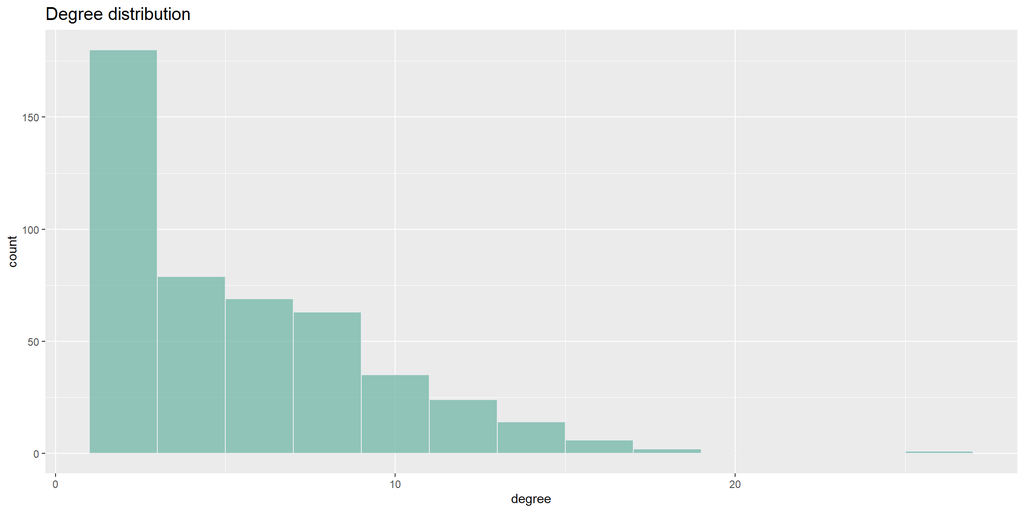

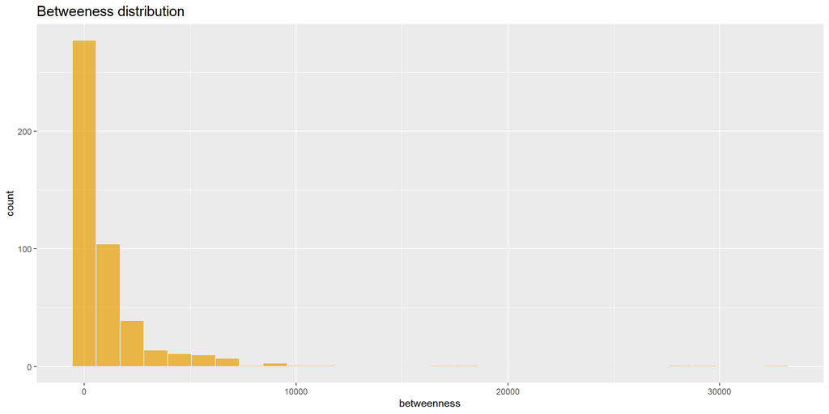

```
            id          label       Ontology   description                                                                                       group            ranking
----------  ----------  ----------  ---------  ------------------------------------------------------------------------------------------------  ------------  ----------
AT5G59820   AT5G59820   AT5G59820   ZAT12      Zinc finger protein ZAT12 [Source:UniProtKB/Swiss-Prot;Acc:Q42410]                                Regulator      0.7845278
AT3G44720   AT3G44720   AT3G44720   ADT4       Arogenate dehydratase 4, chloroplastic [Source:UniProtKB/Swiss-Prot;Acc:O22241]                   Target Gene    0.7307692
AT1G09932   AT1G09932   AT1G09932              Phosphoglycerate mutase family protein [Source:UniProtKB/TrEMBL;Acc:Q8GWG7]                       Target Gene    0.6987443
AT3G44670   AT3G44670   AT3G44670              Disease resistance protein (TIR-NBS-LRR class) family [Source:UniProtKB/TrEMBL;Acc:F4J361]        Target Gene    0.6652810
AT3G57010   AT3G57010   AT3G57010   SSL8       Protein STRICTOSIDINE SYNTHASE-LIKE 8 [Source:UniProtKB/Swiss-Prot;Acc:Q9M1J7]                    Target Gene    0.5893542
AT3G01810   AT3G01810   AT3G01810              EEIG1/EHBP1 protein amino-terminal domain protein [Source:UniProtKB/TrEMBL;Acc:Q9SGJ0]            Target Gene    0.5867375
AT5G39320   AT5G39320   AT5G39320   UGD4       UDP-glucose 6-dehydrogenase 4 [Source:UniProtKB/Swiss-Prot;Acc:Q9FM01]                            Target Gene    0.5343403
AT5G49350   AT5G49350   AT5G49350              At5g49350 [Source:UniProtKB/TrEMBL;Acc:Q84Q60]                                                    Target Gene    0.5258181
AT2G14878   AT2G14878   AT2G14878                                                                                                                Target Gene    0.4890188
AT5G39120   AT5G39120   AT5G39120              Germin-like protein subfamily 1 member 15 [Source:UniProtKB/Swiss-Prot;Acc:Q9FIC9]                Target Gene    0.4772390
AT5G49870   AT5G49870   AT5G49870   JAL48      Jacalin-related lectin 48 [Source:UniProtKB/Swiss-Prot;Acc:Q9LTY2]                                Target Gene    0.4644939
AT3G47950   AT3G47950   AT3G47950   AHA4       Plasma membrane ATPase [Source:UniProtKB/TrEMBL;Acc:A0A178VFQ4]                                   Target Gene    0.4584757
AT1G58030   AT1G58030   AT1G58030   CAT2       Cationic amino acid transporter 2, vacuolar [Source:UniProtKB/Swiss-Prot;Acc:Q9ASS7]              Target Gene    0.4577747
AT4G29905   AT4G29905   AT4G29905              Putative uncharacterized protein [Source:UniProtKB/TrEMBL;Acc:Q940I1]                             Target Gene    0.4170373
AT2G02130   AT2G02130   AT2G02130   PDF2.3     Defensin-like protein 1 [Source:UniProtKB/Swiss-Prot;Acc:Q9ZUL7]                                  Target Gene    0.4147204
AT3G56880   AT3G56880   AT3G56880              VQ motif-containing protein [Source:UniProtKB/TrEMBL;Acc:Q9LES0]                                  Target Gene    0.4114103
AT5G06320   AT5G06320   AT5G06320   NHL3       NHL3 [Source:UniProtKB/TrEMBL;Acc:A0A178UB58]                                                     Target Gene    0.4097308
AT2G28570   AT2G28570   AT2G28570              At2g28570 [Source:UniProtKB/TrEMBL;Acc:Q9SK01]                                                    Target Gene    0.3916451
AT2G45920   AT2G45920   AT2G45920   PUB37      U-box domain-containing protein 37 [Source:UniProtKB/Swiss-Prot;Acc:Q683D5]                       Target Gene    0.3851898
AT1G21400   AT1G21400   AT1G21400              Thiamin diphosphate-binding fold (THDP-binding) superfamily protein [Source:TAIR;Acc:AT1G21400]   Target Gene    0.3831763
```

[interactive chart not shown]

```r
BC3net <- bc3net(dataset = normalized.count[genes, ])
gcc <- getgcc(BC3net)
plotStats(gcc)
```

```r
genie <- genie(normalized.count, regressors = genes, targets = genes, fixedLinkNumber = length(E(gcc)))
```

```
               cNF_3      cNF_2      cNF_1      cnF_2      cnF_1      cnF_3
AT1G01010 1404.48413 1137.14606 1370.49722 1234.59407  975.10562 1079.37253
AT1G01020  382.87379  322.15371  354.90475  337.93987  367.05113  392.30632
AT1G01030   28.53146   16.95546   23.33284   28.08096   36.30176   29.68805
               CNF_1      CnF_2      CnF_1      CnF_3      cNf_1      cnf_2
AT1G01010 1464.91355 1068.19624 1184.65014 1186.87210 2176.34766 2035.52449
AT1G01020  387.67033  484.08540  459.57834  488.14901  431.52528  392.07689
AT1G01030   20.58427   44.35090   31.12682   40.89662   16.84914   38.53336
               cnf_1      cNf_2      cNf_3      cnf_3     Cnf_3      CNf_1
AT1G01010 1879.40582 2023.32331 2118.16807 1941.68207 1766.0503 1878.68429
AT1G01020  370.22495  484.52438  340.48387  469.97319  430.1804  432.82958
AT1G01030   27.42407   34.72162   33.15238   25.27744   37.3297   36.14637
              Cnf_1      Cnf_2      CNf_3      CNf_2      CNF_3      CNF_2
AT1G01010 1666.8990 1566.98344 1652.58184 1823.32023 1342.09996 1267.10176
AT1G01020  404.8455  383.20455  444.05745  443.82189  366.77487  433.48218
AT1G01030   34.2123   36.93538   39.78239   35.54418   24.67096   26.39795
 [ reached getOption("max.print") -- omitted 3 rows ]
 [1] "AT1G01020" "AT1G01090" "AT1G01160" "AT1G01170" "AT1G01470" "AT1G01600"
 [7] "AT1G01610" "AT1G01770" "AT1G01820" "AT1G02300" "AT1G02610" "AT1G02640"
[13] "AT1G02730" "AT1G02840" "AT1G02860" "AT1G03060" "AT1G03090" "AT1G03457"
[19] "AT1G03610" "AT1G03700" "AT1G03850" "AT1G03935" "AT1G04120" "AT1G04220"
[25] "AT1G04360" "AT1G04990" "AT1G05000" "AT1G05575" "AT1G05700" "AT1G05830"
[31] "AT1G05840" "AT1G05890" "AT1G06000" "AT1G06160" "AT1G06570" "AT1G06630"
[37] "AT1G07135" "AT1G08090" "AT1G08230" "AT1G08630" "AT1G08980" "AT1G09070"
[43] "AT1G09140" "AT1G09250" "AT1G09280" "AT1G09780" "AT1G09932" "AT1G10070"
[49] "AT1G10140" "AT1G10220" "AT1G10610" "AT1G10910" "AT1G10920" "AT1G11175"
[55] "AT1G11180" "AT1G11185" "AT1G11260" "AT1G11530" "AT1G11790" "AT1G11920"
[61] "AT1G12010" "AT1G12040" "AT1G12110" "AT1G12440" "AT1G12780" "AT1G12805"
[67] "AT1G13080" "AT1G13250" "AT1G13260" "AT1G13300" "AT1G13710" "AT1G14200"
[73] "AT1G14540" "AT1G14550" "AT1G14640"
 [ reached getOption("max.print") -- omitted 1234 entries ]
 [1] "AT5G61600" "AT4G27450" "AT1G27730" "AT5G51190" "AT1G19530" "AT2G27830"
 [7] "AT4G27280" "AT5G13930" "AT3G44260" "AT5G04340" "AT2G40000" "AT1G33055"
[13] "AT4G27652" "AT5G56100" "AT1G65970" "AT5G19700" "AT3G16770" "AT4G27654"
[19] "AT1G76680" "AT2G48080" "AT2G38600" "AT2G25900" "AT1G05575" "AT3G19030"
[25] "AT4G11650" "AT4G08290" "AT1G73540" "AT5G05270" "AT4G32480" "AT1G54970"
[31] "AT2G34315" "AT2G15880" "AT5G14120" "AT5G51860" "AT3G23810" "AT4G24570"
[37] "AT1G29100" "AT1G18300" "AT5G63160" "AT5G07580" "AT4G29905" "AT5G13580"
[43] "AT2G38110" "AT4G39675" "AT3G57020" "AT3G29000" "AT1G28370" "AT1G70290"
[49] "AT5G66052" "AT5G09520" "AT4G17500" "AT3G54500" "AT1G76590" "AT4G27657"
[55] "AT1G01470" "AT5G39890" "AT4G37520" "AT5G19410" "AT1G49500" "AT3G50400"
[61] "AT1G66500" "AT5G09480" "AT2G39980" "AT4G22690" "AT3G14940" "AT2G18050"
[67] "AT2G35380" "AT5G08640" "AT1G69252" "AT1G73260" "AT1G04220" "AT5G37690"
[73] "AT3G22120" "AT3G23880" "AT2G37750"
 [ reached getOption("max.print") -- omitted 1234 entries ]
[1] "Number of links : 1359"
```

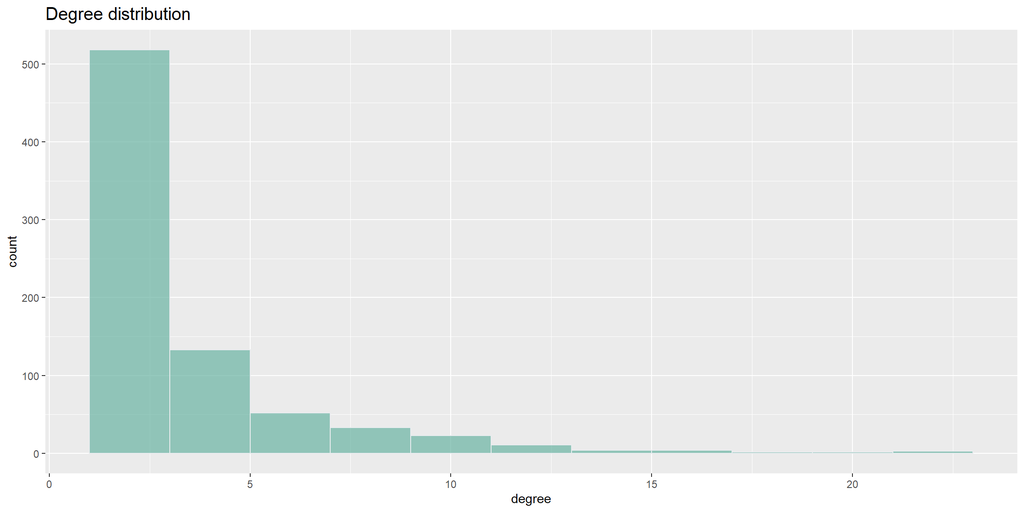

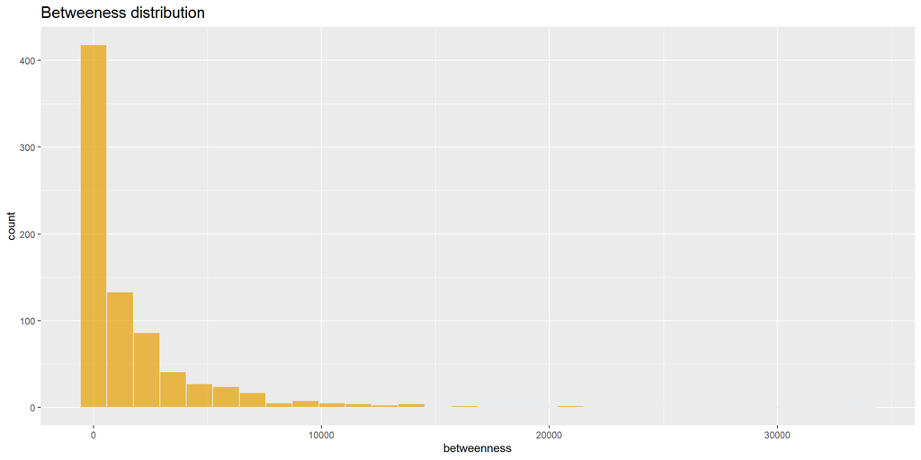

```
            id          label       Ontology     description                                                                                              group            ranking
----------  ----------  ----------  -----------  -------------------------------------------------------------------------------------------------------  ------------  ----------
AT3G48740   AT3G48740   AT3G48740   SWEET11      Bidirectional sugar transporter SWEET11 [Source:UniProtKB/Swiss-Prot;Acc:Q9SMM5]                         Target Gene    0.7826087
AT5G27420   AT5G27420   AT5G27420   ATL31        E3 ubiquitin-protein ligase ATL31 [Source:UniProtKB/Swiss-Prot;Acc:Q8LGA5]                               Target Gene    0.6652457
AT1G43800   AT1G43800   AT1G43800   S-ACP-DES6   Stearoyl-[acyl-carrier-protein] 9-desaturase 6, chloroplastic [Source:UniProtKB/Swiss-Prot;Acc:Q84VY3]   Target Gene    0.6333271
AT5G40390   AT5G40390   AT5G40390   RFS5         Probable galactinol--sucrose galactosyltransferase 5 [Source:UniProtKB/Swiss-Prot;Acc:Q9FND9]            Target Gene    0.5490440
AT3G01175   AT3G01175   AT3G01175                Transmembrane protein [Source:UniProtKB/TrEMBL;Acc:F4J4Q8]                                               Target Gene    0.5430474
AT3G06435   AT3G06435   AT3G06435                At3g06435 [Source:UniProtKB/TrEMBL;Acc:Q3EBB7]                                                           Target Gene    0.5370052
AT1G74460   AT1G74460   AT1G74460                GDSL esterase/lipase At1g74460 [Source:UniProtKB/Swiss-Prot;Acc:Q9CA68]                                  Target Gene    0.5351534
AT5G39890   AT5G39890   AT5G39890   PCO2         Plant cysteine oxidase 2 [Source:UniProtKB/Swiss-Prot;Acc:Q8LGJ5]                                        Target Gene    0.5306382
AT2G44798   AT2G44798   AT2G44798                other RNA [Source:TAIR;Acc:AT2G44798]                                                                    Target Gene    0.5126477
AT1G11260   AT1G11260   AT1G11260   STP1         STP1 [Source:UniProtKB/TrEMBL;Acc:A0A178WJ63]                                                            Target Gene    0.4820135
AT4G10540   AT4G10540   AT4G10540   SBT3.8       Subtilisin-like protease SBT3.8 [Source:UniProtKB/Swiss-Prot;Acc:Q9SZY3]                                 Target Gene    0.4745762
AT1G65970   AT1G65970   AT1G65970   PRXIIC       TPX2 [Source:UniProtKB/TrEMBL;Acc:A0A178WKG0]                                                            Target Gene    0.4514487
AT1G01610   AT1G01610   AT1G01610   GPAT4        GPAT4 [Source:UniProtKB/TrEMBL;Acc:A0A178W9F8]                                                           Target Gene    0.4491632
AT2G41380   AT2G41380   AT2G41380                At2g41380 [Source:UniProtKB/TrEMBL;Acc:Q9ZVC3]                                                           Target Gene    0.4433487
AT3G43190   AT3G43190   AT3G43190   SUS4         Sucrose synthase 4 [Source:UniProtKB/Swiss-Prot;Acc:Q9LXL5]                                              Target Gene    0.4413005
AT3G11370   AT3G11370   AT3G11370                Cysteine/Histidine-rich C1 domain family protein [Source:UniProtKB/TrEMBL;Acc:Q9CAY7]                    Target Gene    0.4363443
AT5G50140   AT5G50140   AT5G50140                Ankyrin repeat family protein [Source:UniProtKB/TrEMBL;Acc:Q9FG97]                                       Target Gene    0.4358958
AT2G16060   AT2G16060   AT2G16060   AHB1         NSHB1 [Source:UniProtKB/TrEMBL;Acc:A0A384KL50]                                                           Target Gene    0.4281580
AT1G03850   AT1G03850   AT1G03850                Glutaredoxin family protein [Source:TAIR;Acc:AT1G03850]                                                  Target Gene    0.4214982
AT1G69160   AT1G69160   AT1G69160                Protein BIG GRAIN 1-like E [Source:UniProtKB/Swiss-Prot;Acc:Q93Z37]                                      Target Gene    0.4197115
```

[interactive chart not shown]

```r
plotStats(genie)
```

```r
base::intersect(as.character(E(gcc)), as.character(E(genie)))
```

```
 [1] "1"  "2"  "3"  "4"  "5"  "6"  "7"  "8"  "9"  "10" "11" "12" "13" "14" "15"
[16] "16" "17" "18" "19" "20" "21" "22" "23" "24" "25" "26" "27" "28" "29" "30"
[31] "31" "32" "33" "34" "35" "36" "37" "38" "39" "40" "41" "42" "43" "44" "45"
[46] "46" "47" "48" "49" "50" "51" "52" "53" "54" "55" "56" "57" "58" "59" "60"
[61] "61" "62" "63" "64" "65" "66" "67" "68" "69" "70" "71" "72" "73" "74" "75"
 [ reached getOption("max.print") -- omitted 1284 entries ]
```

```r
a <- E(gcc)
igraph::intersection(E(gcc)[1:length(E(gcc))], E(genie))
```

```
+ 1359/1359 edges from 48c7ae0 (vertex names):
 [1] AT1G01610--AT1G78990 AT5G22250--AT3G46620 AT1G78990--AT1G77590
 [4] AT4G08380--AT3G09220 AT1G11260--AT3G48360 AT2G41380--AT3G28345
 [7] AT4G20390--AT2G48130 AT5G26690--AT2G24710 AT4G31570--AT3G02260
[10] AT4G38080--AT1G55990 AT4G14440--AT4G36610 AT4G33820--AT1G77590
[13] AT5G26690--AT3G28345 AT1G10220--AT5G27420 AT2G21100--AT3G52790
[16] AT5G10230--AT4G28940 AT4G36610--AT5G41040 AT4G33820--AT3G02260
[19] AT2G21100--AT5G44550 AT5G26690--AT2G24710 AT1G74090--AT5G47560
[22] AT4G38080--AT2G22510 AT1G71340--AT1G55500 AT4G36610--AT5G41040
[25] AT4G24230--AT5G56550 AT5G19730--AT4G13395 AT2G41380--AT1G10220
[28] AT3G45290--AT1G76410 AT1G02640--AT2G31730 AT1G80380--AT1G31230
+ ... omitted several edges
```

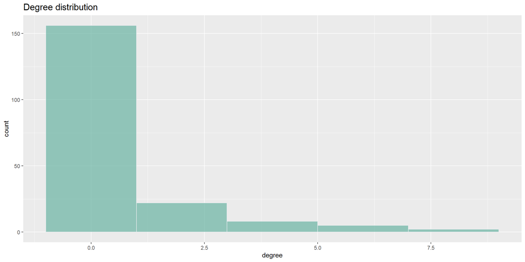

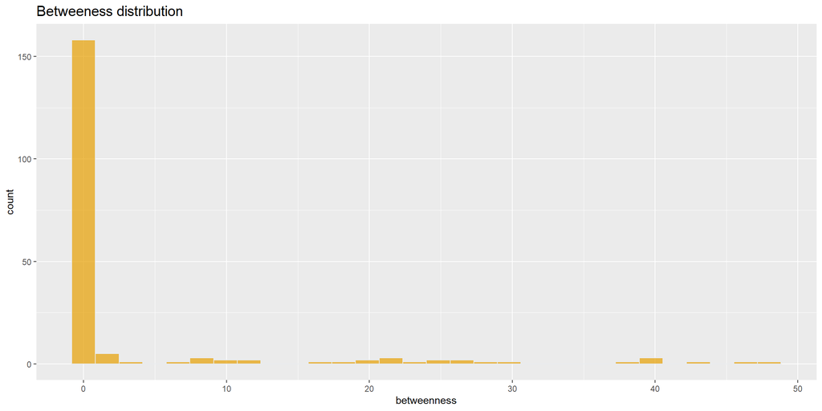

```
            id          label       Ontology     description                                                                                              group            ranking
----------  ----------  ----------  -----------  -------------------------------------------------------------------------------------------------------  ------------  ----------
AT1G43800   AT1G43800   AT1G43800   S-ACP-DES6   Stearoyl-[acyl-carrier-protein] 9-desaturase 6, chloroplastic [Source:UniProtKB/Swiss-Prot;Acc:Q84VY3]   Target Gene    0.9154920
AT3G43190   AT3G43190   AT3G43190   SUS4         Sucrose synthase 4 [Source:UniProtKB/Swiss-Prot;Acc:Q9LXL5]                                              Target Gene    0.8108082
AT2G34390   AT2G34390   AT2G34390   NIP2-1       Aquaporin NIP2-1 [Source:UniProtKB/Swiss-Prot;Acc:Q8W037]                                                Target Gene    0.7669823
AT2G44798   AT2G44798   AT2G44798                other RNA [Source:TAIR;Acc:AT2G44798]                                                                    Target Gene    0.7631614
AT5G39890   AT5G39890   AT5G39890   PCO2         Plant cysteine oxidase 2 [Source:UniProtKB/Swiss-Prot;Acc:Q8LGJ5]                                        Target Gene    0.7047657
AT3G10040   AT3G10040   AT3G10040                Sequence-specific DNA binding transcription factor [Source:UniProtKB/TrEMBL;Acc:Q8RWY5]                  Target Gene    0.6898246
AT3G04370   AT3G04370   AT3G04370   CRRSP39      Cysteine-rich repeat secretory protein 39 [Source:UniProtKB/Swiss-Prot;Acc:Q6E263]                       Target Gene    0.6875000
AT5G37690   AT5G37690   AT5G37690                GDSL esterase/lipase At5g37690 [Source:UniProtKB/Swiss-Prot;Acc:Q9FHQ1]                                  Target Gene    0.6666667
AT3G06435   AT3G06435   AT3G06435                At3g06435 [Source:UniProtKB/TrEMBL;Acc:Q3EBB7]                                                           Target Gene    0.6386679
AT4G27450   AT4G27450   AT4G27450                AT4g27450/F27G19_50 [Source:UniProtKB/TrEMBL;Acc:Q93V62]                                                 Target Gene    0.6363358
AT5G09480   AT5G09480   AT5G09480                At5g09480 [Source:UniProtKB/TrEMBL;Acc:Q9FY67]                                                           Target Gene    0.5937500
AT5G19410   AT5G19410   AT5G19410                ABC-2 type transporter family protein [Source:TAIR;Acc:AT5G19410]                                        Target Gene    0.5416667
AT1G73410   AT1G73410   AT1G73410   ATMYB54      MYB54 [Source:UniProtKB/TrEMBL;Acc:A0A178WGB1]                                                           Regulator      0.5416667
AT3G27220   AT3G27220   AT3G27220                Kelch repeat-containing protein At3g27220 [Source:UniProtKB/Swiss-Prot;Acc:Q9LK31]                       Target Gene    0.5312500
AT2G16060   AT2G16060   AT2G16060   AHB1         NSHB1 [Source:UniProtKB/TrEMBL;Acc:A0A384KL50]                                                           Target Gene    0.5300189
AT5G23190   AT5G23190   AT5G23190   CYP86B1      Cytochrome P450 86B1 [Source:UniProtKB/Swiss-Prot;Acc:Q9FMY1]                                            Target Gene    0.4583333
AT1G49430   AT1G49430   AT1G49430   LACS2        Long chain acyl-CoA synthetase 2 [Source:UniProtKB/Swiss-Prot;Acc:Q9XIA9]                                Target Gene    0.4270833
AT5G13580   AT5G13580   AT5G13580   ABCG6        ABC transporter G family member 6 [Source:UniProtKB/Swiss-Prot;Acc:Q9FNB5]                               Target Gene    0.4166667
AT3G03270   AT3G03270   AT3G03270                AT3G03270 protein [Source:UniProtKB/TrEMBL;Acc:Q8LFK2]                                                   Target Gene    0.4052760
AT3G02550   AT3G02550   AT3G02550   LBD41        LOB domain-containing protein 41 [Source:UniProtKB/Swiss-Prot;Acc:Q9M886]                                Regulator      0.3759101
```

[interactive chart not shown]

```r
inter <- igraph::intersection(gcc, genie, keep.all.vertices = F)
plotStats(inter)
```

Ah…. ben c’est pas beaucoup en commun…… :(